# Lecture 1: Bayesian A/B Testing

How to Make Decisions Under Uncertainty

## Motivating Problem

**Tip**

**Setting:** Version A is the existing treatment. Version B is a new design. After two weeks, B had a higher conversion rate. **Should you switch permanently?**

**Learning Objectives**

- Update beliefs when new data arrives (conjugate update)
- Compute P(B > A) via Monte Carlo
- Interpret posterior distributions and credible intervals
- Explain why P(B > A) ≠ a p-value

## Math Toolkit: Exponent Rule

One rule drives the entire Bayesian update:

$$a^m \times a^n = a^{m+n}$$

**Examples:**

$$\theta^3 \times \theta^5 = \theta^8 \qquad (1-\theta)^4 \times (1-\theta)^6 = (1-\theta)^{10}$$

**Tip**

This is the **only** algebra needed for the derivation.

## Math Toolkit: What a Distribution Is

A number states **one** value. A distribution states **which values are plausible**.

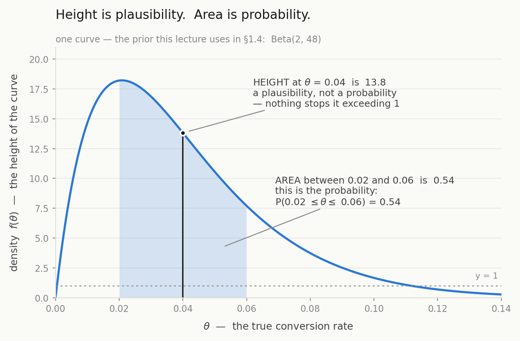

**Height** → plausibility — may exceed 1  
**Area** → probability — the shaded 0.54  
**Total area** → always 1

**Narrow** curve → more certain  
**Wide** curve → less certain  
Data is what narrows it

**Warning**

The curve sits on **θ itself** — an unknown with one fixed true value. It does not wobble; **we** are uncertain about it. That is the whole Bayesian move.

## Math Toolkit: Proportionality (∝)

$$f(\theta) = \underbrace{7}_{\text{constant}} \times \theta^2(1-\theta)^3 \;\propto\; \theta^2(1-\theta)^3$$

**Tip**

The constant doesn’t change the **shape** as θ varies.  
The area under a distribution is always 1, so the constant is fixed automatically — we only need the shape.

**Key pattern to recognize:**

$$\theta^{\alpha-1}(1-\theta)^{\beta-1} \quad\Longrightarrow\quad \text{Beta}(\alpha,\,\beta)$$

## The Problem with Observed Rates

| Variant | Visitors | Conversions | Observed Rate |
| --- | --- | --- | --- |
| A (current) | 600 | 24 | 4.0% |
| B (new) | 600 | 34 | 5.7% |

**Naive answer:** B > A. Switch.

**The real question:**

> Given this data, what is the probability that B’s **true** conversion rate is genuinely higher than A’s?

**Warning**

Observed rates are noisy estimates. Run the experiment again next week and you’d get different numbers.

## Bayesian vs. Frequentist

### p-value

$$p = P(\text{data this extreme} \mid H_0)$$

“How weird is this data if A = B?”

Answers a question nobody is asking.

### Bayesian P(B>A)

$$P(\theta_B > \theta_A \mid \text{data})$$

“How confident am I that B is better?”

Directly answers the decision question.

A small p-value is evidence against the null — not evidence for any specific alternative.

## The Beta Distribution

$$\text{Beta}(\alpha, \beta): \quad f(\theta) \propto \theta^{\alpha-1}(1-\theta)^{\beta-1}, \quad \theta \in [0,1]$$

**Mean:** $\displaystyle E[\theta] = \frac{\alpha}{\alpha + \beta}$

**Spread:** Larger $\alpha + \beta$ → more concentrated

**Prior Beta(2, 48):**

$E[\theta] = \dfrac{2}{50} = 4\%$

Encodes our belief that conversion rates are typically ~4%.

**Tip**

$\alpha + \beta$ is the prior’s weight in pseudo-observations: Beta(2, 48) is worth ~50

## Which Symbol Is Which

**Objects**

P(converts) = 0.04 → a **probability**  
f(θ) → a **density** (a height)  
Beta, Binomial → **families**

**Roles**

Prior → Beta(2, 48)  
Likelihood → the Binomial  
Posterior → *another Beta*

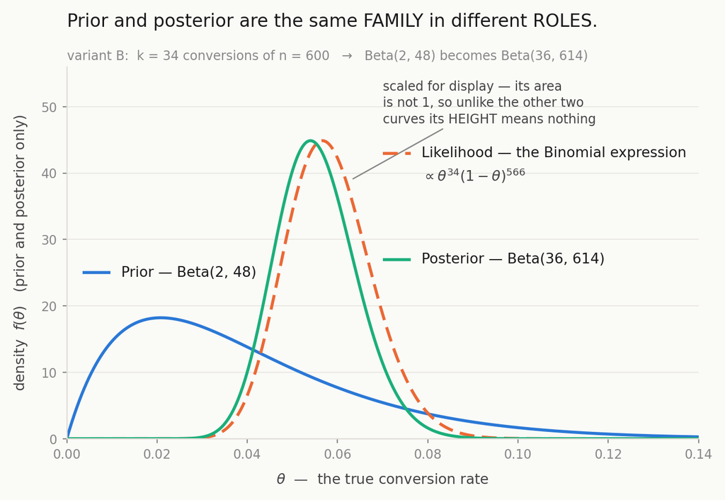

**Warning**

**“Is Beta the prior?” — no.** Beta is a **family**; prior / likelihood / posterior are **roles**. Both Betas are drawn solid because they are the same family; the likelihood is dashed because its area is **not** 1 — it is scaled for display only.

## The Conjugate Update

Prior × Likelihood → Posterior (same family):

$$\underbrace{\text{Beta}(\alpha, \beta)}_{\text{prior}} \;\times\; \underbrace{\theta^k (1-\theta)^{n-k}}_{\text{likelihood}} \;\propto\; \underbrace{\theta^{\alpha+k-1}(1-\theta)^{\beta+(n-k)-1}}_{\text{Beta}(\alpha+k,\; \beta+n-k)}$$

$$\boxed{\text{Posterior} \sim \text{Beta}(\alpha + k,\;\; \beta + n - k)}$$

$k$ = conversions, $n$ = visitors

## Worked Example: Update

**Prior:** Beta(2, 48) → mean = 4%

**Variant A:** 600 visitors, 24 conversions

$$\alpha_A' = 2 + 24 = 26$$
$$\beta_A' = 48 + 576 = 624$$
$$E[\theta_A] = \tfrac{26}{650} = 4.0\%$$

**Variant B:** 600 visitors, 34 conversions

$$\alpha_B' = 2 + 34 = 36$$
$$\beta_B' = 48 + 566 = 614$$
$$E[\theta_B] = \tfrac{36}{650} = 5.54\%$$

**Tip**

Posterior means are pulled slightly toward the prior (4%) compared to raw rates (4.0% and 5.67%).

## What a “Draw” Is

**One draw** = one value of θ, picked at random, with the curve setting the odds.

**100,000 draws** = a stand-in for the curve.

Histogram them and the posterior comes back.

So anything you’d need to **integrate** for, you can now get by **counting**.

**Warning**

**“Sample” means two different things in this lecture.** In §1.3 it was *the visitors we observed*. Here it is *one value of θ drawn from a curve*. “100,000 samples from Posterior_A” is **not** 100,000 visitors — it is 100,000 guesses at A’s true rate.

## Computing P(B > A) via Monte Carlo

```python
import numpy as np
np.random.seed(42)

theta_a = np.random.beta(26, 624, 100_000)   # draw from posterior A
theta_b = np.random.beta(36, 614, 100_000)   # draw from posterior B

P_B_greater = np.mean(theta_b > theta_a)     # fraction where B wins
expected_lift = np.mean((theta_b - theta_a) / theta_a * 100)
ci_lower = np.percentile((theta_b - theta_a) / theta_a * 100, 2.5)
ci_upper = np.percentile((theta_b - theta_a) / theta_a * 100, 97.5)
```

$$P(\theta_B > \theta_A) \approx \frac{1}{S}\sum_{s=1}^{S} \mathbf{1}\!\left[\tilde{\theta}_B^{(s)} > \tilde{\theta}_A^{(s)}\right]$$

$S = 100{,}000$ samples. Result: **P(B > A) ≈ 0.905**

**Warning**

**The pairing matters.** Draw $s$ from B is compared against draw $s$ from A — one plausible θ_A beside one plausible θ_B is one complete scenario. Valid because the posteriors are **independent**. Never sort either array.

## Interpreting the Output

For this experiment: P(B > A) ≈ 0.905

**What it means:**

Given our prior and the observed data, there is a **90.5% posterior probability** that B’s true conversion rate exceeds A’s.

Direct answer to the decision question.

**What it does NOT mean:**

“B wins 90.5% of repeated experiments”  
(that’s frequentist language)

“There is a 9.5% chance of a Type I error”  
(that’s a p-value)

**Warning**

The interpretation error is the most common mistake on quizzes.

## Credible Interval vs. Confidence Interval

**95% credible interval on lift:**
$$\text{CI} = \left[\text{Percentile}_{2.5}\!\left(\frac{\theta_B - \theta_A}{\theta_A}\right),\; \text{Percentile}_{97.5}\!\left(\frac{\theta_B - \theta_A}{\theta_A}\right)\right]$$

### Credible interval

“There is a **95% probability** the true lift is in **this** interval.”

A statement about the **parameter**.

### Confidence interval

“**95% of intervals** built this way would contain the true lift.”

A statement about the **procedure**.

**Warning**

The endpoints are often nearly identical. What differs is what you may *claim* — the probability sentence everyone wants to say is licensed **only** by the credible interval.

## Reading the Interval: Width vs. Direction

Narrow interval → high precision  
→ confident about magnitude

Wide interval → low precision  
→ magnitude uncertain

**Warning**

**Width and direction are separate questions.** The direction is settled only when the interval **excludes 0** — wide or narrow. [−1%, +2%] is narrow and leaves it open; [8%, 75%] is wide and settles it.

A 95% interval sits entirely above 0 exactly when P(B>A) > 0.975 — the lower bound *is* the 2.5th percentile.

## Decision Threshold for Implementation

No universal threshold exists. The appropriate criterion depends on:

| Factor | Lower threshold OK | Need higher threshold |
| --- | --- | --- |
| Cost of being wrong | Cheap to reverse | Slow/costly to reverse |
| Stakes | Small feature | Core pricing change |
| Magnitude | Credible interval is all-positive | CI includes negative lifts |

**Tip**

**Empirical guideline:** P ≥ 0.90 is commonly used for low-cost, reversible decisions. P ≥ 0.95–0.97 is appropriate when reversal is costly or the decision affects a large population.

## Checkpoint

1. P(B>A) = 0.91. Your manager says “B wins 91 out of 100 repeated experiments.” Correct?
2. Prior: Beta(2, 48). Observe: 56 conversions, 800 visitors. What is the posterior?
3. Would the posterior mean be above or below the raw rate 56/800 = 7.0%? Why?
4. A colleague demands a p-value < 0.05. What do you say?
5. P(B>A) = 0.76. The change takes 3 months to reverse. Do you implement the change?

Discuss in pairs. Answers in the lecture notes, under “Slide Checkpoint Answers” (numbered to match this slide).